# Course Project of Practical Machine Learning

Nick Lin

21 November, 2015

## Goal

It is to predict the manner in which exercisers did the exercise by using data from ccelerometers on the belt, forearm, arm, and dumbell of 6 participants. They were asked to perform barbell lifts correctly and incorrectly in 5 different ways. More information is available from the website[^1] (see the section on the Weight Lifting Exercise Dataset). And we are going to realize the class’ framework, ‘Components of a Predictor’: question->input data->features->algorithm->parameters->evaluation, to build this prediction model.

```r
library(caret)
library(rattle)
```

## Question

Which type[^2] of weight lifting exercise is performed given that data from ccelerometers on the belt, forearm, arm, and dumbell?

## Input Data

The training data for this project are available [here](https://d396qusza40orc.cloudfront.net/predmachlearn/pml-training.csv); The test data are available [here](https://d396qusza40orc.cloudfront.net/predmachlearn/pml-testing.csv). Be noticed the test data set is used for submitting your predictions for automated grading(apparently, it got no the target variable “classe”), not for evaluating your built model such as out-of-sample error estimation.

Download the files, and then read them in.

```r
if (!file.exists("./pml-training.csv")) {
  fileURL <- "https://d396qusza40orc.cloudfront.net/predmachlearn/pml-training.csv"
  download.file(fileURL, destfile = "./pml-training.csv", method = "curl")
}
if (!file.exists("./pml-testing.csv")) {
  fileURL <- "https://d396qusza40orc.cloudfront.net/predmachlearn/pml-testing.csv"
  download.file(fileURL, destfile = "./pml-testing.csv", method = "curl")
}
trainData <- read.csv("./pml-training.csv", na.strings = c("NA", "", "\"\"", "#DIV/0!"))
testData <- read.csv("./pml-testing.csv", na.strings = c("NA", "", "\"\"", "#DIV/0!"))
```

## Features

Explore the data and preprocess it if needed before building models.

```r
dim(trainData)
```

```
## [1] 19622   160
```

There are 19,622 observations and 159 variables(except the target variable, “classe”) in the training data set.

```r
summary(trainData)
```

```
##        X            user_name    raw_timestamp_part_1 raw_timestamp_part_2
##  Min.   :    1   adelmo  :3892   Min.   :1.322e+09    Min.   :   294
##  1st Qu.: 4906   carlitos:3112   1st Qu.:1.323e+09    1st Qu.:252912
##  Median : 9812   charles :3536   Median :1.323e+09    Median :496380
##  Mean   : 9812   eurico  :3070   Mean   :1.323e+09    Mean   :500656
##  3rd Qu.:14717   jeremy  :3402   3rd Qu.:1.323e+09    3rd Qu.:751891
##  Max.   :19622   pedro   :2610   Max.   :1.323e+09    Max.   :998801
##
##           cvtd_timestamp  new_window    num_window      roll_belt
##  28/11/2011 14:14: 1498   no :19216   Min.   :  1.0   Min.   :-28.90
##  05/12/2011 11:24: 1497   yes:  406   1st Qu.:222.0   1st Qu.:  1.10
##  30/11/2011 17:11: 1440               Median :424.0   Median :113.00
##  05/12/2011 11:25: 1425               Mean   :430.6   Mean   : 64.41
##  02/12/2011 14:57: 1380               3rd Qu.:644.0   3rd Qu.:123.00
##  02/12/2011 13:34: 1375               Max.   :864.0   Max.   :162.00
##  (Other)         :11007
##    pitch_belt          yaw_belt       total_accel_belt kurtosis_roll_belt
##  Min.   :-55.8000   Min.   :-180.00   Min.   : 0.00    Min.   :-2.121
##  1st Qu.:  1.7600   1st Qu.: -88.30   1st Qu.: 3.00    1st Qu.:-1.329
##  Median :  5.2800   Median : -13.00   Median :17.00    Median :-0.899
##  Mean   :  0.3053   Mean   : -11.21   Mean   :11.31    Mean   :-0.220
##  3rd Qu.: 14.9000   3rd Qu.:  12.90   3rd Qu.:18.00    3rd Qu.:-0.219
##  Max.   : 60.3000   Max.   : 179.00   Max.   :29.00    Max.   :33.000
##                                                        NA's   :19226
##  kurtosis_picth_belt kurtosis_yaw_belt skewness_roll_belt
##  Min.   :-2.190      Mode:logical      Min.   :-5.745
##  1st Qu.:-1.107      NA's:19622        1st Qu.:-0.444
##  Median :-0.151                        Median : 0.000
##  Mean   : 4.334                        Mean   :-0.026
##  3rd Qu.: 3.178                        3rd Qu.: 0.417
##  Max.   :58.000                        Max.   : 3.595
##  NA's   :19248                         NA's   :19225
##  skewness_roll_belt.1 skewness_yaw_belt max_roll_belt     max_picth_belt
##  Min.   :-7.616       Mode:logical      Min.   :-94.300   Min.   : 3.00
##  1st Qu.:-1.114       NA's:19622        1st Qu.:-88.000   1st Qu.: 5.00
##  Median :-0.068                         Median : -5.100   Median :18.00
##  Mean   :-0.296                         Mean   : -6.667   Mean   :12.92
##  3rd Qu.: 0.661                         3rd Qu.: 18.500   3rd Qu.:19.00
##  Max.   : 7.348                         Max.   :180.000   Max.   :30.00
##  NA's   :19248                          NA's   :19216     NA's   :19216
```

[output cut: 313 more lines]

```
##  Min.   :-446.00   Min.   :-1280.0   Min.   :-896.0   Min.   :-973.0
##  1st Qu.:-182.00   1st Qu.: -616.0   1st Qu.:   2.0   1st Qu.: 191.0
##  Median : -39.00   Median : -378.0   Median : 591.0   Median : 511.0
##  Mean   : -55.29   Mean   : -312.6   Mean   : 380.1   Mean   : 393.6
##  3rd Qu.:  26.00   3rd Qu.:  -73.0   3rd Qu.: 737.0   3rd Qu.: 653.0
##  Max.   : 291.00   Max.   :  672.0   Max.   :1480.0   Max.   :1090.0
##
##  classe
##  A:5580
##  B:3797
##  C:3422
##  D:3216
##  E:3607
##
##
```

After a preliminary feature exploration, we typically impute data in following directions:

- Dealing Missing Value  
  At first, there might be variables having high ratio of missing value, we wonder the remaining nonNAs can still provide classification power, say, like NAs vs. nonNAs, and would like to leave them as they are. But after a series of tries on train(){caret}, we found some methods perform “omit” operation which deletes cases if a null encountered resulting in very sparse samples (200+) for training. Weighing the trade-off, we decide to drop variables having nulls to keep the samples.
- Standardization/Transformation  
  Since the question is a multi-classification problem, non-linear one. We do not particularly standarize/transform variables.
- Eliminating variable if less interpretative to the target or highly correlated to others  
  We reduce the number of candidate variables to save time by dropping zero-variance variables which have no discriminating power. As for correlation or colinearity, again, this is a classification problem, we do not put this issue in consideration.

```r
#find variables with nulls
nullVars <- colnames(trainData[colSums(is.na(trainData)) > 0])
#find variables with constant value, ie. zero-variance
nzv <- nearZeroVar(trainData, saveMetrics = TRUE)
print(nzv[nzv$zeroVar == TRUE,]) #list all zero-variance variables
```

```
##                        freqRatio percentUnique zeroVar  nzv
## kurtosis_yaw_belt              0    0.00000000    TRUE TRUE
## skewness_yaw_belt              0    0.00000000    TRUE TRUE
## amplitude_yaw_belt             0    0.00509632    TRUE TRUE
## kurtosis_yaw_dumbbell          0    0.00000000    TRUE TRUE
## skewness_yaw_dumbbell          0    0.00000000    TRUE TRUE
## amplitude_yaw_dumbbell         0    0.00509632    TRUE TRUE
## kurtosis_yaw_forearm           0    0.00000000    TRUE TRUE
## skewness_yaw_forearm           0    0.00000000    TRUE TRUE
## amplitude_yaw_forearm          0    0.00509632    TRUE TRUE
```

```r
conVars <- rownames(nzv[nzv$zeroVar == TRUE,])
#drop all variables found in previous steps, plus first 7 which are descriptive like participant's name and timestamp info
screenedTrainData <- trainData[, ! names(trainData) %in% c(nullVars, conVars)][, -c(1:7)]
```

Finally, we get a downsized data, 52 candidate variables plus 1 target variable.  
Then we split it into two independent sets, one for model building(60%), and the other for model evaluation(40%), ie. out-of-sample error.

```r
set.seed(1234)
inTrain <- createDataPartition(screenedTrainData$classe, p=0.6, list=FALSE)
myTraining <- screenedTrainData[inTrain,]
myTesting <- screenedTrainData[-inTrain,]
dim(myTraining); dim(myTesting)
```

```
## [1] 11776    53
```

```
## [1] 7846   53
```

## Algorithm/Parameters

An algorithm usually is accompanied with several tuning parameters. We might try different combinations of algorithms and parameters, so we consider these two components as a whole as a stage of modeling cycle.

We consider the following algorithms to develop the prediction model.

1. Decision Tree  
   Intuitively selected because it’s a classification problem, and considered as benchmark.
2. Random Forest  
   One of most recommended approaches with significant performance.
3. Boosting  
   One of most recommended approaches with significant performance.

Then we utilize cross-validation resamplings specified in trainControl(){caret} to determine best parameter set, say, 4-fold cross-validation, instead of default bootstrapping which bit of underestimates the error and is computationally intensive.

#### Decision Tree (method=“rpart” in train()/{caret})

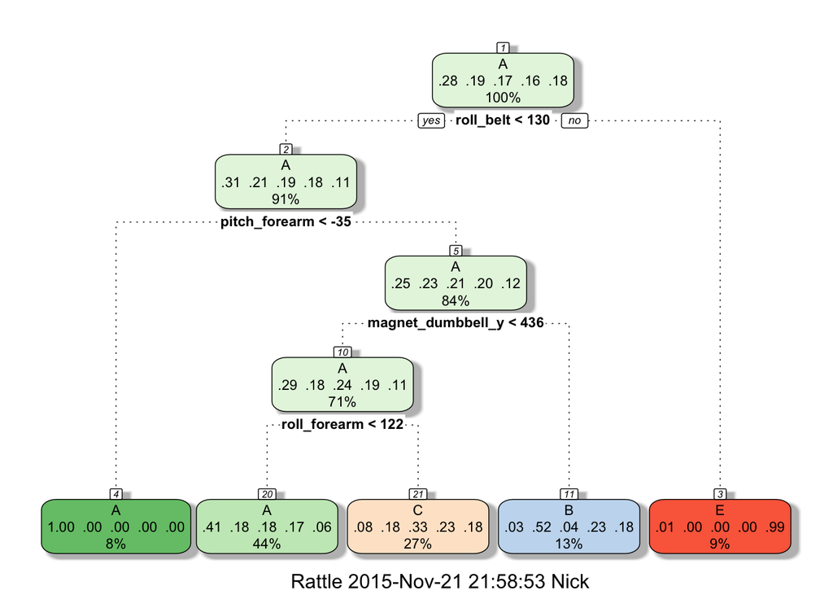

```r
set.seed(1234)
modDT <- train(classe ~ ., data = myTraining, method = "rpart", trControl = trainControl(method = "cv", number = 4))
fancyRpartPlot(modDT$finalModel)
```

```r
print(modDT)
```

```
## CART
##
## 11776 samples
##    52 predictor
##     5 classes: 'A', 'B', 'C', 'D', 'E'
##
## No pre-processing
## Resampling: Cross-Validated (4 fold)
## Summary of sample sizes: 8832, 8833, 8832, 8831
## Resampling results across tuning parameters:
##
##   cp          Accuracy   Kappa      Accuracy SD  Kappa SD
##   0.03618889  0.5103608  0.3609118  0.007931406  0.01071881
##   0.06110584  0.4309618  0.2330552  0.071349907  0.11998300
##   0.11651637  0.3459581  0.0938768  0.041121349  0.06261137
##
## Accuracy was used to select the optimal model using  the largest value.
## The final value used for the model was cp = 0.03618889.
```

```r
predTrainDT <- predict(modDT, myTraining)
confusionMatrix(predTrainDT, myTraining$classe)
```

```
## Confusion Matrix and Statistics
##
##           Reference
## Prediction    A    B    C    D    E
##          A 3032  910  941  861  312
##          B   51  798   60  348  284
##          C  255  571 1053  721  577
##          D    0    0    0    0    0
##          E   10    0    0    0  992
##
## Overall Statistics
##
##                Accuracy : 0.4989
##                  95% CI : (0.4898, 0.508)
##     No Information Rate : 0.2843
##     P-Value [Acc > NIR] : < 2.2e-16
##
##                   Kappa : 0.3456
##  Mcnemar's Test P-Value : NA
##
## Statistics by Class:
##
##                      Class: A Class: B Class: C Class: D Class: E
## Sensitivity            0.9056  0.35015  0.51266   0.0000  0.45820
## Specificity            0.6412  0.92176  0.78153   1.0000  0.99896
## Pos Pred Value         0.5007  0.51785  0.33144      NaN  0.99002
## Neg Pred Value         0.9448  0.85530  0.88359   0.8361  0.89113
## Prevalence             0.2843  0.19353  0.17442   0.1639  0.18385
## Detection Rate         0.2575  0.06776  0.08942   0.0000  0.08424
## Detection Prevalence   0.5143  0.13086  0.26979   0.0000  0.08509
## Balanced Accuracy      0.7734  0.63596  0.64709   0.5000  0.72858
```

We can tell that cross-validation averaged accuracy is 51.04% (used to pick up best parameter set for modeling); in-sample accuracy estimate is 49.89%, applying final model with best parameter set to whole training data)

#### Random Forest (method=“rf” in train()/{caret})

```r
set.seed(1234)
modRF <- train(classe ~ ., data = myTraining, method = "rf", trControl = trainControl(method = "cv", number = 4))
print(modRF)
```

```
## Random Forest
##
## 11776 samples
##    52 predictor
##     5 classes: 'A', 'B', 'C', 'D', 'E'
##
## No pre-processing
## Resampling: Cross-Validated (4 fold)
## Summary of sample sizes: 8832, 8833, 8832, 8831
## Resampling results across tuning parameters:
##
##   mtry  Accuracy   Kappa      Accuracy SD  Kappa SD
##    2    0.9880268  0.9848512  0.001781213  0.002255300
##   27    0.9883661  0.9852819  0.001370560  0.001734211
##   52    0.9819122  0.9771163  0.004406945  0.005570420
##
## Accuracy was used to select the optimal model using  the largest value.
## The final value used for the model was mtry = 27.
```

```r
predTrainRF <- predict(modRF, myTraining)
confusionMatrix(predTrainRF, myTraining$classe)
```

```
## Confusion Matrix and Statistics
##
##           Reference
## Prediction    A    B    C    D    E
##          A 3348    0    0    0    0
##          B    0 2279    0    0    0
##          C    0    0 2054    0    0
##          D    0    0    0 1930    0
##          E    0    0    0    0 2165
##
## Overall Statistics
##
##                Accuracy : 1
##                  95% CI : (0.9997, 1)
##     No Information Rate : 0.2843
##     P-Value [Acc > NIR] : < 2.2e-16
##
##                   Kappa : 1
##  Mcnemar's Test P-Value : NA
##
## Statistics by Class:
##
##                      Class: A Class: B Class: C Class: D Class: E
## Sensitivity            1.0000   1.0000   1.0000   1.0000   1.0000
## Specificity            1.0000   1.0000   1.0000   1.0000   1.0000
## Pos Pred Value         1.0000   1.0000   1.0000   1.0000   1.0000
## Neg Pred Value         1.0000   1.0000   1.0000   1.0000   1.0000
## Prevalence             0.2843   0.1935   0.1744   0.1639   0.1838
## Detection Rate         0.2843   0.1935   0.1744   0.1639   0.1838
## Detection Prevalence   0.2843   0.1935   0.1744   0.1639   0.1838
## Balanced Accuracy      1.0000   1.0000   1.0000   1.0000   1.0000
```

Cross-validation averaged accuracy is 98.84%; in-sample accuracy estimate is 100%.

#### Boosting (method=“gbm” in train()/{caret})

```r
set.seed(1234)
modBST <- train(classe ~ ., data = myTraining, method = "gbm", trControl = trainControl(method = "cv", number = 4), verbose = FALSE)
print(modBST)
```

```
## Stochastic Gradient Boosting
##
## 11776 samples
##    52 predictor
##     5 classes: 'A', 'B', 'C', 'D', 'E'
##
## No pre-processing
## Resampling: Cross-Validated (4 fold)
## Summary of sample sizes: 8832, 8833, 8832, 8831
## Resampling results across tuning parameters:
##
##   interaction.depth  n.trees  Accuracy   Kappa      Accuracy SD
##   1                   50      0.7502544  0.6835742  0.012001025
##   1                  100      0.8158121  0.7669834  0.007328623
##   1                  150      0.8502883  0.8106346  0.003034240
##   2                   50      0.8524114  0.8130349  0.005832410
##   2                  100      0.9077787  0.8832912  0.004975318
##   2                  150      0.9307069  0.9123191  0.002660406
##   3                   50      0.8937680  0.8655409  0.009458975
##   3                  100      0.9414064  0.9258628  0.002543298
##   3                  150      0.9604284  0.9499399  0.002447819
##   Kappa SD
##   0.015278920
##   0.009276828
##   0.003706898
##   0.007391231
##   0.006308066
##   0.003403965
##   0.011971175
##   0.003229428
##   0.003105548
##
## Tuning parameter 'shrinkage' was held constant at a value of 0.1
##
## Tuning parameter 'n.minobsinnode' was held constant at a value of 10
## Accuracy was used to select the optimal model using  the largest value.
## The final values used for the model were n.trees = 150,
##  interaction.depth = 3, shrinkage = 0.1 and n.minobsinnode = 10.
```

```r
predTrainBST <- predict(modBST, myTraining)
confusionMatrix(predTrainBST, myTraining$classe)
```

```
## Confusion Matrix and Statistics
##
##           Reference
## Prediction    A    B    C    D    E
##          A 3318   49    0    3    1
##          B   21 2197   35    6   12
##          C    6   33 1997   46   17
##          D    2    0   20 1869   28
##          E    1    0    2    6 2107
##
## Overall Statistics
##
##                Accuracy : 0.9755
##                  95% CI : (0.9726, 0.9783)
##     No Information Rate : 0.2843
##     P-Value [Acc > NIR] : < 2.2e-16
##
##                   Kappa : 0.9691
##  Mcnemar's Test P-Value : 2.008e-11
##
## Statistics by Class:
##
##                      Class: A Class: B Class: C Class: D Class: E
## Sensitivity            0.9910   0.9640   0.9722   0.9684   0.9732
## Specificity            0.9937   0.9922   0.9895   0.9949   0.9991
## Pos Pred Value         0.9843   0.9674   0.9514   0.9739   0.9957
## Neg Pred Value         0.9964   0.9914   0.9941   0.9938   0.9940
## Prevalence             0.2843   0.1935   0.1744   0.1639   0.1838
## Detection Rate         0.2818   0.1866   0.1696   0.1587   0.1789
## Detection Prevalence   0.2863   0.1928   0.1782   0.1630   0.1797
## Balanced Accuracy      0.9924   0.9781   0.9809   0.9817   0.9861
```

Cross-validation averaged accuracy is 96.04%; in-sample accuracy estimate is 97.55%.

## Evaluation

Given that in-sample accuracy of each model, we got a basic idea of how they perform. Now we apply those models on the other independent data set to confirm each unbiased estimate of error rate.

#### Decision Tree

```r
predTestDT <- predict(modDT, myTesting)
confusionMatrix(predTestDT, myTesting$classe)
```

```
## Confusion Matrix and Statistics
##
##           Reference
## Prediction    A    B    C    D    E
##          A 2029  638  644  567  209
##          B   44  505   49  232  211
##          C  155  375  675  487  383
##          D    0    0    0    0    0
##          E    4    0    0    0  639
##
## Overall Statistics
##
##                Accuracy : 0.4904
##                  95% CI : (0.4793, 0.5016)
##     No Information Rate : 0.2845
##     P-Value [Acc > NIR] : < 2.2e-16
##
##                   Kappa : 0.3339
##  Mcnemar's Test P-Value : NA
##
## Statistics by Class:
##
##                      Class: A Class: B Class: C Class: D Class: E
## Sensitivity            0.9091  0.33267  0.49342   0.0000  0.44313
## Specificity            0.6334  0.91530  0.78388   1.0000  0.99938
## Pos Pred Value         0.4965  0.48511  0.32530      NaN  0.99378
## Neg Pred Value         0.9460  0.85114  0.87992   0.8361  0.88852
## Prevalence             0.2845  0.19347  0.17436   0.1639  0.18379
## Detection Rate         0.2586  0.06436  0.08603   0.0000  0.08144
## Detection Prevalence   0.5209  0.13268  0.26447   0.0000  0.08195
## Balanced Accuracy      0.7712  0.62399  0.63865   0.5000  0.72125
```

The unbiased estimate of out-of-sample error is (1-0.4904)=50.96%.

#### Random Forest

```r
predTestRF <- predict(modRF, myTesting)
confusionMatrix(predTestRF, myTesting$classe)
```

```
## Confusion Matrix and Statistics
##
##           Reference
## Prediction    A    B    C    D    E
##          A 2231   19    0    0    0
##          B    0 1494   10    1    2
##          C    1    5 1350   21    2
##          D    0    0    8 1262    4
##          E    0    0    0    2 1434
##
## Overall Statistics
##
##                Accuracy : 0.9904
##                  95% CI : (0.988, 0.9925)
##     No Information Rate : 0.2845
##     P-Value [Acc > NIR] : < 2.2e-16
##
##                   Kappa : 0.9879
##  Mcnemar's Test P-Value : NA
##
## Statistics by Class:
##
##                      Class: A Class: B Class: C Class: D Class: E
## Sensitivity            0.9996   0.9842   0.9868   0.9813   0.9945
## Specificity            0.9966   0.9979   0.9955   0.9982   0.9997
## Pos Pred Value         0.9916   0.9914   0.9790   0.9906   0.9986
## Neg Pred Value         0.9998   0.9962   0.9972   0.9963   0.9988
## Prevalence             0.2845   0.1935   0.1744   0.1639   0.1838
## Detection Rate         0.2843   0.1904   0.1721   0.1608   0.1828
## Detection Prevalence   0.2868   0.1921   0.1758   0.1624   0.1830
## Balanced Accuracy      0.9981   0.9911   0.9912   0.9898   0.9971
```

#### Boosting

```r
predTestBST <- predict(modBST, myTesting)
confusionMatrix(predTestBST, myTesting$classe)
```

```
## Confusion Matrix and Statistics
##
##           Reference
## Prediction    A    B    C    D    E
##          A 2203   51    0    0    2
##          B   18 1425   50    6   29
##          C    5   40 1289   42    9
##          D    5    1   24 1230   18
##          E    1    1    5    8 1384
##
## Overall Statistics
##
##                Accuracy : 0.9599
##                  95% CI : (0.9553, 0.9641)
##     No Information Rate : 0.2845
##     P-Value [Acc > NIR] : < 2.2e-16
##
##                   Kappa : 0.9492
##  Mcnemar's Test P-Value : 1.808e-10
##
## Statistics by Class:
##
##                      Class: A Class: B Class: C Class: D Class: E
## Sensitivity            0.9870   0.9387   0.9423   0.9565   0.9598
## Specificity            0.9906   0.9837   0.9852   0.9927   0.9977
## Pos Pred Value         0.9765   0.9326   0.9307   0.9624   0.9893
## Neg Pred Value         0.9948   0.9853   0.9878   0.9915   0.9910
## Prevalence             0.2845   0.1935   0.1744   0.1639   0.1838
## Detection Rate         0.2808   0.1816   0.1643   0.1568   0.1764
## Detection Prevalence   0.2875   0.1947   0.1765   0.1629   0.1783
## Balanced Accuracy      0.9888   0.9612   0.9637   0.9746   0.9787
```

We can either pick Random Forest model as our champion model and apply it on the project submission cases.

Or we can think about improving the accuracy by model stacking or majority vote, etc. Let’s compare the predictions on the test set across models and actual values. Retrieve cases in which the prediction by Random Forest is incorrect, and check out what the predictions are made by the other two.

```r
predTest <- data.frame(predTestDT, predTestRF, predTestBST, classe = myTesting$classe)
table(predTest[myTesting$classe!=predTestRF, -2])
```

```
## , , classe = A
##
##           predTestBST
## predTestDT  A  B  C  D  E
##          A  0  0  1  0  0
##          B  0  0  0  0  0
##          C  0  0  0  0  0
##          D  0  0  0  0  0
##          E  0  0  0  0  0
##
## , , classe = B
##
##           predTestBST
## predTestDT  A  B  C  D  E
##          A 17  1  4  0  0
##          B  0  0  0  0  0
##          C  0  1  1  0  0
##          D  0  0  0  0  0
##          E  0  0  0  0  0
##
## , , classe = C
##
##           predTestBST
## predTestDT  A  B  C  D  E
##          A  0  5  0  3  0
##          B  0  3  0  0  0
##          C  0  1  4  2  0
##          D  0  0  0  0  0
##          E  0  0  0  0  0
##
## , , classe = D
##
##           predTestBST
## predTestDT  A  B  C  D  E
##          A  0  0  8  0  0
##          B  0  1  0  0  0
##          C  0  0 14  0  1
##          D  0  0  0  0  0
##          E  0  0  0  0  0
##
## , , classe = E
##
##           predTestBST
## predTestDT  A  B  C  D  E
##          A  0  0  0  0  1
##          B  0  1  0  1  0
##          C  0  0  2  3  0
##          D  0  0  0  0  0
##          E  0  0  0  0  0
```

We can tell the other two, Decision Tree and Boosting, can not come to significant agreement to improve the accuracy. Let’s directly apply Random Forest model on the 20 cases for submission.

## Prediction on 20 cases for Project Submission

```r
ans <- predict(modRF, testData)
pml_write_files = function(x){
  n = length(x)
  for(i in 1:n){
    filename = paste0("problem_id_",i,".txt")
    write.table(x[i],file=filename,quote=FALSE,row.names=FALSE,col.names=FALSE)
  }
}
pml_write_files(ans)
```

[^1]: http://groupware.les.inf.puc-rio.br/har
[^2]: There are five types of exercise: exactly according to the specification (Class A), throwing the elbows to the front (Class B), lifting the dumbbell only halfway (Class C), lowering the dumbbell only halfway (Class D) and throwing the hips to the front (Class E).